## Definición de nuestro sistema

$$\begin{align}
\large
\dot{x}(t) = v(t)
\end{align}$$

$$\begin{align}
\large
\dot{v}(t) =
\begin{cases}
-\frac{b_a}{m} \cdot v(t) - g & \text{si $x(t) > 0$} \\
-\frac{k}{m} \cdot x(t) -\frac{b}{m} \cdot v(t) - g & \text{si $x(t) \leq 0$}
\end{cases}
\end{align}$$

## # **Desarrollo Analítico**

Lo primero a realizar para poder desarrollar la solución analítica de nuestro problema está en realizar el análisis por partes del problema. Para ir en orden, analicemos las caídas primero.

1. Caída libre

Al tener como altura inicial $S(0) = 10$, tenemos que usar la ecuación $\dot{v}(t) = -\frac{b_a}{m} \cdot v(t) - g$ para poder determinar la aceleración. Para poder determinar la aceleración respecto al tiempo, gracias a las condiciones iniciales que nos dan ($v(0)=0$, $S(0)=10$)

Remplazando por las constantes dadas para el sistema ($b_a = 0.1$, $m = 1$, $g = 9.8$), tenemos la ecuación resultante:

$$\begin{align}
\dot{v}(t) = -\frac{0.1}{1} \cdot v(t) - 9.8 \\
10 \cdot \ddot{x}(t) = - \dot{x}(t) - 98
\end{align}$$

Despejamos a la izquierda para igualar a $0$ nuestra ecuacion:

$$\begin{align}
10 \cdot \ddot{x}(t) + \dot{x}(t) + 98 = 0
\end{align}$$

Y aplicamos la transformada de Laplace a ambos lados

$$\begin{align}
\mathscr{L}[10 \cdot \ddot{x}(t) + \dot{x}(t) + 98] = \mathscr{L}[0]
\end{align}$$
$$\begin{align}
\mathscr{L}[10 \cdot \ddot{x}(t)] + \mathscr{L}[\dot{x}(t)] + \mathscr{L}[98] = \mathscr{L}[0]
\end{align}$$
$$\begin{align}
\frac{98}{s} + 10s^2 \cdot (\mathscr{L}[x(t)](s)) - s \cdot x(0) - \dot{x}(0) + s \cdot
(\mathscr{L}[x(t)](s)) - x(0) = 0
\end{align}$$
$$\begin{align}
\mathscr{L}[x(t)](s)) \cdot (10s^2 + s) - x(0) \cdot (s+1) + \frac{98}{s} - \dot{x}(0) =0
\end{align}$$
$$\begin{align}
\mathscr{L}[x(t)](s)) = \frac{-\frac{98}{s} + \dot{x}(0) + (s+1) \cdot x(0)}{10s^2+s}
\end{align}$$
$$\begin{align}
\mathscr{L}[x(t)](s)) = \frac{-98 + s \cdot \dot{x}(0) + s \cdot (s+1) \cdot x(0)}{s^2(10s+1)}
\end{align}$$

Aplicamos fracciones parciales

$$\begin{align}
\mathscr{L}[x(t)](s)) = -\frac{98}{s^2} + \frac{980}{s} - \frac{9800}{10s+1} + \frac{x(0)}{s} + \frac{10 \cdot
\dot{x}(0)}{s} - \frac{100 \cdot \dot{x}(0)}{10s+1}
\end{align}$$

Aplicamos la trasnformada inversa de Laplace

$$\begin{align}
\mathscr{L}^{-1}[\mathscr{L}[x(t)](s))] = \mathscr{L}^{-1}\left[-\frac{98}{s^2} + \frac{980}{s} -
\frac{9800}{10s+1} + \frac{x(0)}{s} + \frac{10 \cdot \dot{x}(0)}{s} - \frac{100 \cdot \dot{x}(0)}{10s+1} \right]
\end{align}$$
$$\begin{align}
x(t) = -98t + 980 - 980 \cdot e^{-t/10}+x(0)+10 \cdot \dot{x}(0)- 10 \cdot e^{-t/10} \cdot \dot{x(0)}
\end{align}$$

Simplificamos
$$\begin{align}
x(t) = -98t + (10 \cdot \dot{x}(0) + 980) \cdot (1 - e^{-t/10}) + x(0)
\end{align}$$

Y remplazamos las condiciones iniciales

$$\begin{align}
x(t) = -98t + (10 \cdot 0 + 980) \cdot (1 - e^{-t/10}) + 10
\end{align}$$

Lo que nos deja con la ecuación:

$$\begin{align}
x(t) = -98t + 990 - 980 \cdot e^{-t/10}
\end{align}$$

2. Rebote

Implementaremos el metodo de coeficientes indeterminados para calcular el resultado de la ecuación diferencial. Para esto tenemos en cuenta que la solución se encuentra conformada por:

$$\begin{align}
x = x_{c} + x_{p}
\end{align}$$

Para dar solución a nuestra ecuación diferencial debemos igualarla a $0$:

Cambiamos las variables de las derivadas por variables del mismo nivel de potencia:

$$\begin{align}
m^{2}+300\cdot m+1000000= 0
\end{align}$$

Teniendo en cuenta las reglas del metodo de coeficientes indeterminados tenemos una solución de la forma:

$$\begin{align}
x_{c} = C_{1}\cdot e^{\alpha}\cdot cos({\beta \cdot x}) + C_{2}\cdot e^{\alpha}\cdot sen({\beta \cdot x})
\end{align}$$

Basandonos en esto, la solución complementaria quedaría de la siguiente manera:

Teniendo la solución complementaria estructurada, realizaremos el proceso para encontrar la solución particular. Tomaremos el caso donde $y_{p}= A$. Teniendo esto en cuenta, se obtiene el siguiente resultado:

$$\begin{align}
x_{p} = A
\end{align}$$
$$\begin{align}
\dot{x_{p}} = 0
\end{align}$$
$$\begin{align}
\ddot{x_{p}} = 0
\end{align}$$

Reemplazando en la ecuación diferencial tenemos:

$$\begin{align}
0+{300} \cdot 0+1000000\cdot A= - 9.8
\end{align}$$
$$\begin{align}
1000000\cdot A= - 9.8
\end{align}$$
$$\begin{align}
A = \frac{-9.8}{1000000}
\end{align}$$
$$\begin{align}
A = - \frac{49}{5000000}
\end{align}$$

Ahora se unen las dos respuestas obtenidas para encontrar la solución general de la ecuación diferencial:

Por motivos de simplicidad, para la solución particular se omitirá el proceso ya que es demasiado extenso el proceso, teniendo esto en cuenta, la solución obtenida es la siguiente:

$$\begin{align}
x = \frac{\frac{147\cdot sen(50\cdot \sqrt{391\cdot x})}{5000000\cdot \sqrt{391}} + \frac{49\cdot cos(50\cdot \sqrt{391\cdot x})}{5000000}}{e^{150\cdot x}} - \frac{49}{5000000}
\end{align}$$

## # **Desarrollo de la simulación**

Importamos las librerías de `numpy` y `matplot`

```python
import numpy as np
import matplotlib.pyplot as plt
```

Definimos nuestro delta general, el tiempo y los parámetros de la simulación.

```python
delta = 0.000001 # Delta con el que se trabajará durante toda la simulación
tiempoTotal = 10 # segundos

# Constantes dadas para la definición del sistema
ba = 0.1
m = 1
b = 30
g = 9.8
k = 100000
```

A partir de esto, calculamos la cantidad de puntos que vamos a trabajar y definimos los espacios lineales para el tiempo (Discretización del tiempo).

```python
nSteps = int(tiempoTotal/delta)
tSpace = np.linspace(0, tiempoTotal, nSteps + 1)

print(f"Cantidad de pasos de tiempo: {nSteps}")
```

```
## Cantidad de pasos de tiempo: 10000000
```

```python
print(f"Espacio lineal de tiempo: {tSpace}")
```

```
## Espacio lineal de tiempo: [0.000000e+00 1.000000e-06 2.000000e-06 ... 9.999998e+00 9.999999e+00
##  1.000000e+01]
```

Ahora tenemos que declarar nuestro sistema definido por ecuaciones de diferencias.

```python
# Declaramos la función de la aceleración
def acceleration(position, speed, ba = ba, b = b, m = m, k = k, g = g):
    if position > 0:
        return -(ba/m) * speed - g
    else:
        return -(k/m) * position - (b/m) * speed - g

# No es necesario declarar funciones de Velocidad (v(t) = a(t) * t) ni posición (s(t) = v(t) * t)
# Por lo que estas dependen directamente de la aceleración y no prensentan condiciones especiales
```

A partir de nuestra función de aceleración (`acceleration`), podemos realizar nuestra simulación.

```python
# Establecemos nuestras condiciones iniciales
v = 0 # m/s
s = 10 # m
a = 0

# Creamos los vectores que contienen los valores calculados de aceleración, velocidad y posición
all_v = np.zeros(nSteps) # Vector de las velocidades
all_s = np.zeros(nSteps) # Vector de las posiciones
all_a = np.zeros(nSteps) # Vector de las aceleraciones

for indx in range(nSteps):
    # Primero calculamos la aceleración
    a = acceleration(s, v)
    # Calculamos la posición
    s = s + v * delta
    # Y finalmente la velocidad para la siguiente iteración
    v = v + a * delta

    # Y registramos todos los valores calculados en los vectores correspondientes
    all_s[indx] = s
    all_a[indx] = a
    all_v[indx] = v
```

Ahora, realizamos la graficación de nuestros valores simulados

```python
plt.rcParams["figure.figsize"] = (30,10)
```

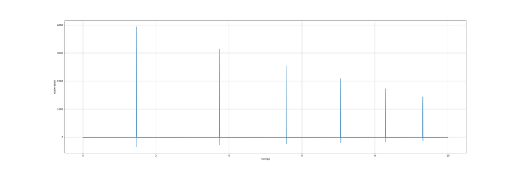

```python
plt.plot(tSpace[:-1], all_a)
plt.ylabel("Aceleracion")
plt.xlabel("Tiempo")
plt.grid()
plt.show()
```

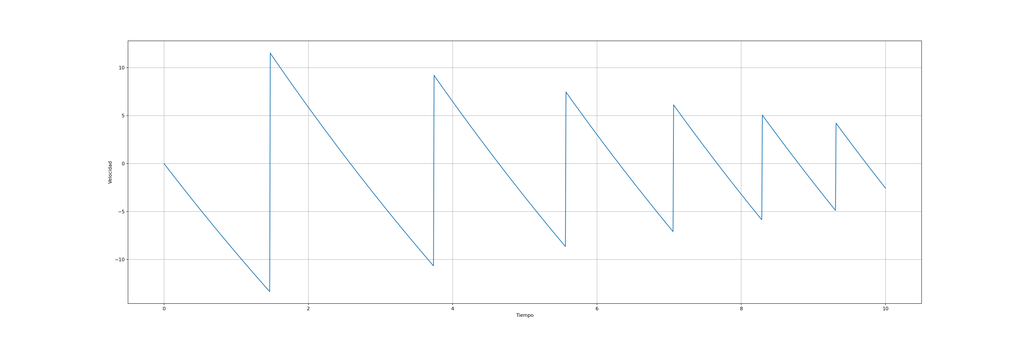

```python
plt.plot(tSpace[:-1], all_v)
plt.ylabel("Velocidad")
plt.xlabel("Tiempo")
plt.grid()
plt.show()
```

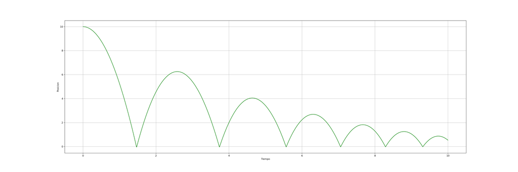

```python
plt.plot(tSpace[:-1], all_s, color= "green")
plt.ylabel("Posicion")
plt.xlabel("Tiempo")
plt.grid()
plt.show()
```